```python
from IPython.display import Image
from adsy.ipython import extended_styles
extended_styles()
```

Toggle Input

# Progress Report for Project Firestorm

## SFT-Nets and Graphical Structure

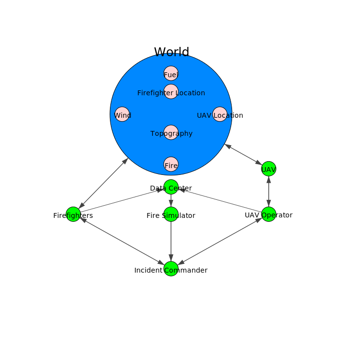

```python
Image('./sft_presentations/combined_graph.png', width=600)
```

- Each node has an internal state.
  - For example, the state of the UAV can be "connected" or "not connected".
- Nodes can send "messages" along their directed edges.
  - ex. the UAV operator can send motion instructions to the UAV
- Nodes can change their state either spontaneously or when they receive a message
  - ex. The UAV can spontaneously "drop out" and change its state from connected to not connected, or the UAV can change the direction it is moving when it receives a message from the UAV operator.
- Parameters of the Physical System are set a priori.
- Parameters of the human agents are optimized.
  - Humans can choose to change their state and send messages.
- **If the duration between message transmission and state transition are exponential, then an SFT-Net defines an event-driven (Markov) stochastic process**

## Optimal Strategies and Monte Carlo Tree Search

- MCTS provides a mapping from what a player "knows" to how a player acts.
- In an SFT-Net, the player will likely not know the state of the system (all nodes) at all times. Therefore he has partial observability.
- What does he know?
  - His state and the messages he sends
  - Messages he receives
  - *Time that he receives messages*
- Recall a POMDP is defined by a (State, Action, Observation, Transition Probability and Reward)
- In an SFT-Net, the **rewards** are specified and the **transition probabilities** are determined by the generator
- The **state** of the system is the state of all nodes in the network.
- A player's action can either be a specific action at a specific time or an element of the **generator** matrix.
- A player's observation includes the state of his own node as well as the messages he receives.
- *The main issue is that if the time of the messages matter, then the space of the history will be infinite*.